## Red Wine Classification - Amish Kapoor

**Part A:** Background and Data Exploration

4. Importing the red wine dataset

```r
red_wine <- read.csv("D:/MS Business Analytics – University of Cincinnati/Classroom Notes and Exercises/Summer 2021/BANA - Statistical Modelling/Final_Take_Home_Assignment/Dataset/winequality-red.csv", sep = ";")

head(red_wine)
```

```
##   fixed.acidity volatile.acidity citric.acid residual.sugar chlorides
## 1           7.4             0.70        0.00            1.9     0.076
## 2           7.8             0.88        0.00            2.6     0.098
## 3           7.8             0.76        0.04            2.3     0.092
## 4          11.2             0.28        0.56            1.9     0.075
## 5           7.4             0.70        0.00            1.9     0.076
## 6           7.4             0.66        0.00            1.8     0.075
##   free.sulfur.dioxide total.sulfur.dioxide density   pH sulphates alcohol
## 1                  11                   34  0.9978 3.51      0.56     9.4
## 2                  25                   67  0.9968 3.20      0.68     9.8
## 3                  15                   54  0.9970 3.26      0.65     9.8
## 4                  17                   60  0.9980 3.16      0.58     9.8
## 5                  11                   34  0.9978 3.51      0.56     9.4
## 6                  13                   40  0.9978 3.51      0.56     9.4
##   quality
## 1       5
## 2       5
## 3       5
## 4       6
## 5       5
## 6       5
```

Summary statistics for each variable in the dataset

```r
summary(red_wine)
```

```
##  fixed.acidity   volatile.acidity  citric.acid    residual.sugar
##  Min.   : 4.60   Min.   :0.1200   Min.   :0.000   Min.   : 0.900
##  1st Qu.: 7.10   1st Qu.:0.3900   1st Qu.:0.090   1st Qu.: 1.900
##  Median : 7.90   Median :0.5200   Median :0.260   Median : 2.200
##  Mean   : 8.32   Mean   :0.5278   Mean   :0.271   Mean   : 2.539
##  3rd Qu.: 9.20   3rd Qu.:0.6400   3rd Qu.:0.420   3rd Qu.: 2.600
##  Max.   :15.90   Max.   :1.5800   Max.   :1.000   Max.   :15.500
##    chlorides       free.sulfur.dioxide total.sulfur.dioxide    density
##  Min.   :0.01200   Min.   : 1.00       Min.   :  6.00       Min.   :0.9901
##  1st Qu.:0.07000   1st Qu.: 7.00       1st Qu.: 22.00       1st Qu.:0.9956
##  Median :0.07900   Median :14.00       Median : 38.00       Median :0.9968
##  Mean   :0.08747   Mean   :15.87       Mean   : 46.47       Mean   :0.9967
##  3rd Qu.:0.09000   3rd Qu.:21.00       3rd Qu.: 62.00       3rd Qu.:0.9978
##  Max.   :0.61100   Max.   :72.00       Max.   :289.00       Max.   :1.0037
##        pH          sulphates         alcohol         quality
##  Min.   :2.740   Min.   :0.3300   Min.   : 8.40   Min.   :3.000
##  1st Qu.:3.210   1st Qu.:0.5500   1st Qu.: 9.50   1st Qu.:5.000
##  Median :3.310   Median :0.6200   Median :10.20   Median :6.000
##  Mean   :3.311   Mean   :0.6581   Mean   :10.42   Mean   :5.636
##  3rd Qu.:3.400   3rd Qu.:0.7300   3rd Qu.:11.10   3rd Qu.:6.000
##  Max.   :4.010   Max.   :2.0000   Max.   :14.90   Max.   :8.000
```

```r
str(red_wine)
```

```
## 'data.frame':    1599 obs. of  12 variables:
##  $ fixed.acidity       : num  7.4 7.8 7.8 11.2 7.4 7.4 7.9 7.3 7.8 7.5 ...
##  $ volatile.acidity    : num  0.7 0.88 0.76 0.28 0.7 0.66 0.6 0.65 0.58 0.5 ...
##  $ citric.acid         : num  0 0 0.04 0.56 0 0 0.06 0 0.02 0.36 ...
##  $ residual.sugar      : num  1.9 2.6 2.3 1.9 1.9 1.8 1.6 1.2 2 6.1 ...
##  $ chlorides           : num  0.076 0.098 0.092 0.075 0.076 0.075 0.069 0.065 0.073 0.071 ...
##  $ free.sulfur.dioxide : num  11 25 15 17 11 13 15 15 9 17 ...
##  $ total.sulfur.dioxide: num  34 67 54 60 34 40 59 21 18 102 ...
##  $ density             : num  0.998 0.997 0.997 0.998 0.998 ...
##  $ pH                  : num  3.51 3.2 3.26 3.16 3.51 3.51 3.3 3.39 3.36 3.35 ...
##  $ sulphates           : num  0.56 0.68 0.65 0.58 0.56 0.56 0.46 0.47 0.57 0.8 ...
##  $ alcohol             : num  9.4 9.8 9.8 9.8 9.4 9.4 9.4 10 9.5 10.5 ...
##  $ quality             : int  5 5 5 6 5 5 5 7 7 5 ...
```

**Part B:** Visualization and Initial Models for a Binary Response

**1. Creating a new binary variable excellent based on the given condition**

```r
red_wine$excellent <- ifelse(red_wine$quality >=7,1,0)

str(red_wine$excellent)
```

```
##  num [1:1599] 0 0 0 0 0 0 0 1 1 0 ...
```

Removing Duplicate Rows from the Dataset

```r
sum(duplicated(red_wine))
```

```
## [1] 240
```

```r
library(dplyr)
red_wine1 <- red_wine %>% distinct(fixed.acidity, volatile.acidity, citric.acid, residual.sugar,chlorides, free.sulfur.dioxide, total.sulfur.dioxide, density, pH,sulphates,alcohol,quality,excellent, .keep_all = TRUE)
```

After removing duplicates, we have 1359 unique observations and 13 variables

**2. Calculating the proportion of excellent red wine (i.e., excellent == 1)**

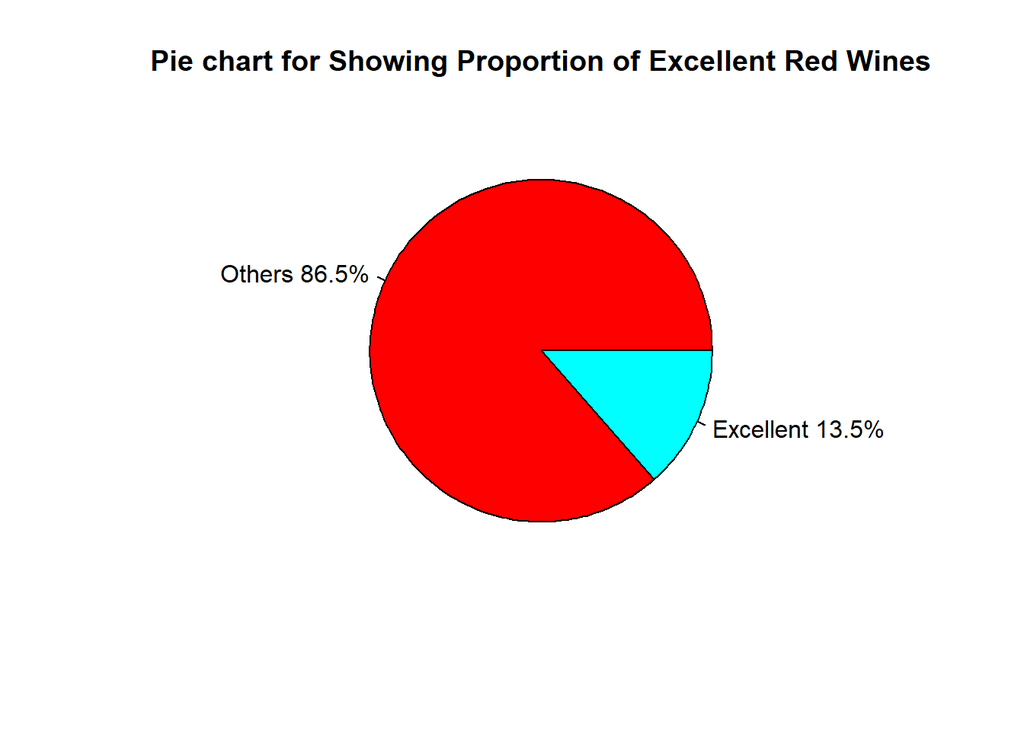

```r
pie_chart <- round(table(red_wine1$excellent)/length(red_wine1$excellent)*100, 1)
labls <- c("Others", "Excellent")
labls <- paste(labls, pie_chart)
labls <- paste(labls, "%", sep = "")
pie(table(red_wine1$excellent), labels = labls, col = rainbow(length(labls)), main = "Pie chart for Showing Proportion of Excellent Red Wines")
```

**3. Visualizing the association between the binary response “excellent” and each of the explanatory variables/predictors**

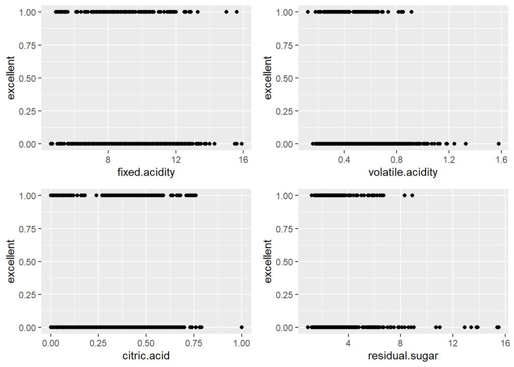

```r
library(ggplot2)
library(gridExtra)
p1 <- ggplot(red_wine1, aes(x = fixed.acidity, y = excellent)) + geom_point()
p2 <- ggplot(red_wine1, aes(x = volatile.acidity, y = excellent)) + geom_point()
p3 <- ggplot(red_wine1, aes(x = citric.acid, y = excellent)) + geom_point()
p4 <- ggplot(red_wine1, aes(x = residual.sugar, y = excellent)) + geom_point()

grid.arrange(p1, p2,p3, p4, nrow = 2, ncol = 2)
```

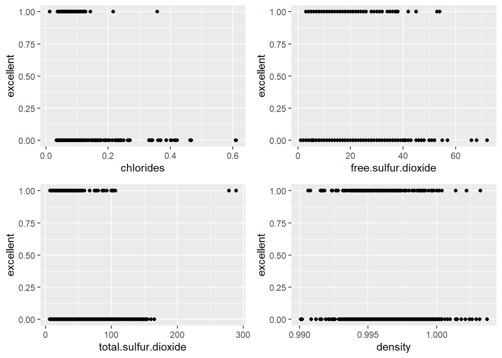

```r
p5 <- ggplot(red_wine1, aes(x = chlorides , y = excellent)) + geom_point()
p6 <- ggplot(red_wine1, aes(x = free.sulfur.dioxide, y = excellent)) + geom_point()
p7 <- ggplot(red_wine1, aes(x = total.sulfur.dioxide, y = excellent)) + geom_point()
p8 <- ggplot(red_wine1, aes(x = density, y = excellent)) + geom_point()

grid.arrange(p5, p6, p7, p8, nrow = 2, ncol = 2)
```

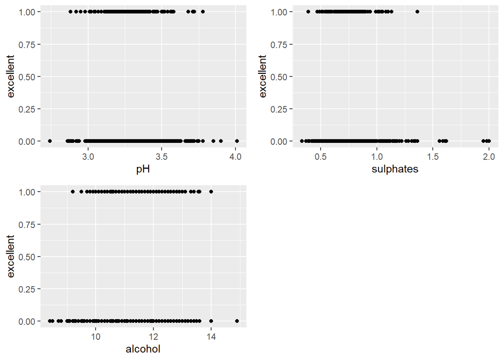

```r
p9 <- ggplot(red_wine1, aes(x = pH, y = excellent)) + geom_point()
p10 <- ggplot(red_wine1, aes(x = sulphates, y = excellent)) + geom_point()
p11 <- ggplot(red_wine1, aes(x = alcohol, y = excellent)) + geom_point()

grid.arrange(p9 ,p10, p11, nrow = 2, ncol = 2)
```

Clearly, we can see some sort of relation between each predictor variable and binary response for quality

Let’s visualize further to see the association

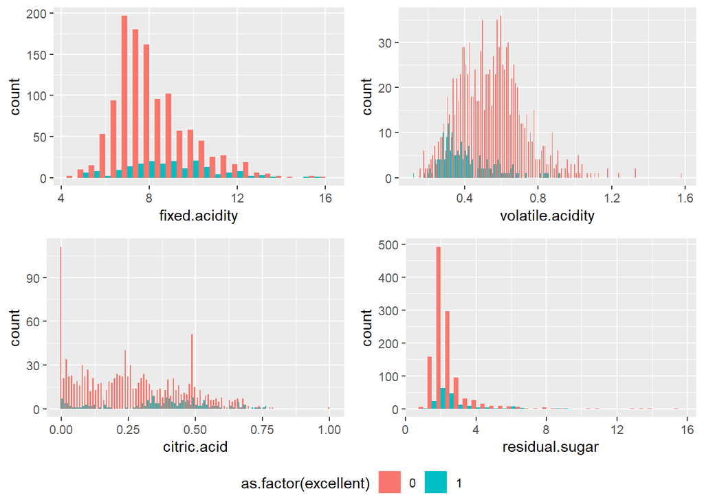

```r
library(ggpubr)

q1 <- ggplot(red_wine1,aes(x=fixed.acidity,fill=as.factor(excellent)))+ geom_histogram(position="dodge",binwidth = 0.5)
q2 <- ggplot(red_wine1,aes(x=volatile.acidity,fill=as.factor(excellent)))+ geom_histogram(position="dodge",binwidth = 0.01)
q3 <- ggplot(red_wine1,aes(x=citric.acid,fill=as.factor(excellent)))+ geom_histogram(position="dodge",binwidth = 0.01)
q4 <- ggplot(red_wine1,aes(x= residual.sugar,fill=as.factor(excellent)))+ geom_histogram(position="dodge",binwidth = 0.5)

ggarrange(q1, q2,q3, q4, nrow = 2, ncol = 2, common.legend = TRUE, legend = "bottom")
```

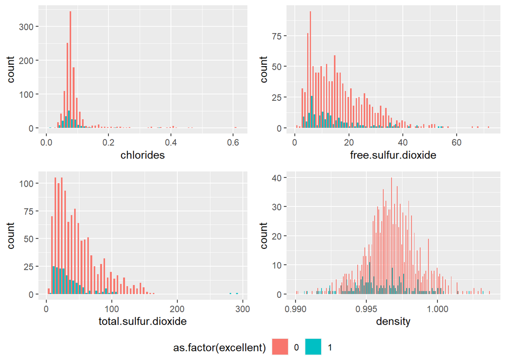

```r
q5 <- ggplot(red_wine1,aes(x=chlorides,fill=as.factor(excellent)))+ geom_histogram(position="dodge",binwidth = 0.01)
q6 <- ggplot(red_wine1,aes(x=free.sulfur.dioxide,fill=as.factor(excellent)))+ geom_histogram(position="dodge",binwidth = 1)
q7 <- ggplot(red_wine1,aes(x=total.sulfur.dioxide,fill=as.factor(excellent)))+ geom_histogram(position="dodge",binwidth = 5)
q8 <- ggplot(red_wine1,aes(x= density,fill=as.factor(excellent)))+ geom_histogram(position="dodge",binwidth = 0.0001)

ggarrange(q5, q6,q7, q8, nrow = 2, ncol = 2, common.legend = TRUE, legend = "bottom")
```

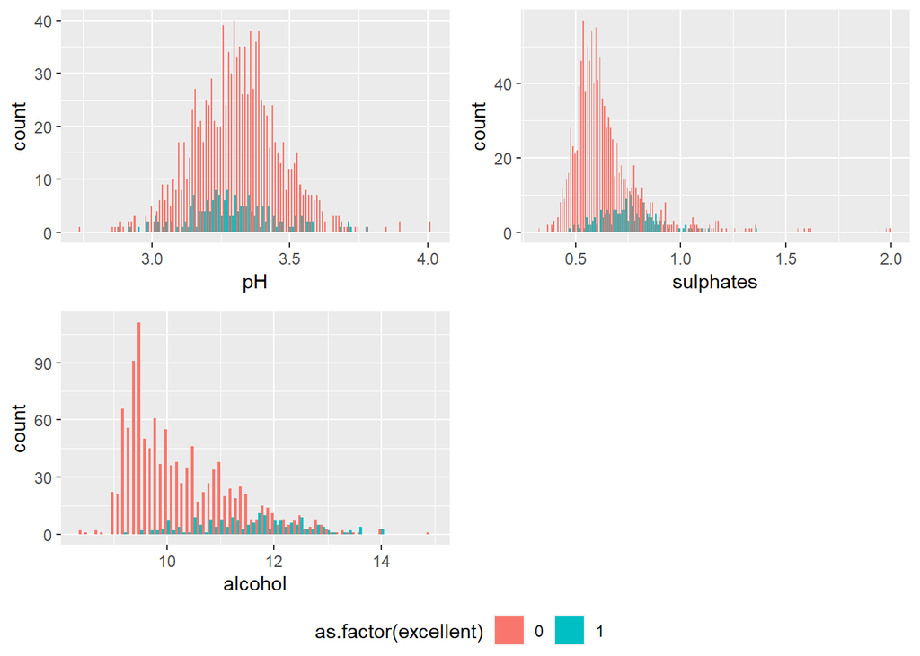

```r
q9 <- ggplot(red_wine1,aes(x=pH,fill=as.factor(excellent)))+ geom_histogram(position="dodge",binwidth = 0.01)
q10 <- ggplot(red_wine1,aes(x=sulphates,fill=as.factor(excellent)))+ geom_histogram(position="dodge",binwidth = 0.01)
q11 <- ggplot(red_wine1,aes(x=alcohol,fill=as.factor(excellent)))+ geom_histogram(position="dodge",binwidth = 0.1)

ggarrange(q9, q10,q11, nrow = 2, ncol = 2, common.legend = TRUE, legend = "bottom")
```

Clearly, we can see some sort of relation with the excellent across variables,hence, keeping all the variables in the model as of now.

**4. Fitting the linear model**

```r
model1 <- lm(excellent ~ . -quality, data = red_wine1)
summary(model1)
```

```
##
## Call:
## lm(formula = excellent ~ . - quality, data = red_wine1)
##
## Residuals:
##      Min       1Q   Median       3Q      Max
## -0.92527 -0.17699 -0.03965  0.05041  0.99903
##
## Coefficients:
##                        Estimate Std. Error t value Pr(>|t|)
## (Intercept)           3.464e+01  1.067e+01   3.245 0.001202 **
## fixed.acidity         3.555e-02  1.313e-02   2.709 0.006837 **
## volatile.acidity     -1.964e-01  5.916e-02  -3.320 0.000924 ***
## citric.acid           3.386e-02  7.342e-02   0.461 0.644693
## residual.sugar        2.438e-02  7.695e-03   3.168 0.001568 **
## chlorides            -6.122e-01  2.035e-01  -3.008 0.002674 **
## free.sulfur.dioxide  -9.372e-04  1.086e-03  -0.863 0.388179
## total.sulfur.dioxide -4.538e-04  3.619e-04  -1.254 0.210136
## density              -3.587e+01  1.089e+01  -3.294 0.001013 **
## pH                    1.220e-02  9.655e-02   0.126 0.899506
## sulphates             3.619e-01  5.763e-02   6.280 4.55e-10 ***
## alcohol               7.711e-02  1.330e-02   5.798 8.37e-09 ***
## ---
## Signif. codes:  0 '***' 0.001 '**' 0.01 '*' 0.05 '.' 0.1 ' ' 1
##
## Residual standard error: 0.2993 on 1347 degrees of freedom
## Multiple R-squared:  0.2417, Adjusted R-squared:  0.2355
## F-statistic: 39.03 on 11 and 1347 DF,  p-value: < 2.2e-16
```

Following are the key points from the above model:

- From the above summary, we can see that we have a very low value for adjusted R-square
- Statistically significant variables are fixed acidity, volatile acidity, residual sugar, chlorides, density, sulphates and alcohol
- Also, volatile acidity, chlorides, free sulphur dioxide, total sulphur dioxide and density have negative association with the binary response ‘excellent’, while the remaining predictor varibales have positive association with the same

**5. Using Logistic Regression to fit the same model**

```r
model2 <- glm(excellent ~ . -quality , data = red_wine1, family = binomial(link = 'logit'))
summary(model2)
```

```
##
## Call:
## glm(formula = excellent ~ . - quality, family = binomial(link = "logit"),
##     data = red_wine1)
##
## Deviance Residuals:
##     Min       1Q   Median       3Q      Max
## -3.0227  -0.4369  -0.2165  -0.1247   3.0037
##
## Coefficients:
##                        Estimate Std. Error z value Pr(>|z|)
## (Intercept)           2.449e+02  1.186e+02   2.064 0.038995 *
## fixed.acidity         3.105e-01  1.398e-01   2.221 0.026324 *
## volatile.acidity     -3.114e+00  8.643e-01  -3.604 0.000314 ***
## citric.acid          -1.790e-01  9.270e-01  -0.193 0.846864
## residual.sugar        2.298e-01  8.043e-02   2.857 0.004270 **
## chlorides            -7.232e+00  3.286e+00  -2.201 0.027768 *
## free.sulfur.dioxide   3.691e-03  1.326e-02   0.278 0.780704
## total.sulfur.dioxide -1.306e-02  5.112e-03  -2.554 0.010649 *
## density              -2.601e+02  1.212e+02  -2.147 0.031825 *
## pH                    2.499e-01  1.097e+00   0.228 0.819857
## sulphates             3.818e+00  5.895e-01   6.477 9.38e-11 ***
## alcohol               7.597e-01  1.435e-01   5.294 1.20e-07 ***
## ---
## Signif. codes:  0 '***' 0.001 '**' 0.01 '*' 0.05 '.' 0.1 ' ' 1
##
## (Dispersion parameter for binomial family taken to be 1)
##
##     Null deviance: 1077.72  on 1358  degrees of freedom
## Residual deviance:  738.26  on 1347  degrees of freedom
## AIC: 762.26
##
## Number of Fisher Scoring iterations: 6
```

Following are the key summary points for logistic regression:

- Fixed acidity, volatile acidity, residual sugar, chlorides, total sulphur dioxide, density, sulphates and alcohol are statistically significant varibales; we can see that total sulphur dioxide was not coming out to be statistically significant in the linear model
- Also, volatile acidity, citric acid, chlorides, total sulphur dioxide and density have negative association with the binary response ‘excellent’, while the remaining predictor varibales have positive association with the same

**Part C.** Variable Selection, Interpretation, and Prediction for a logistic model

**1. Find collinearity in the dataset, then see which one you should pick, after that do model selection using AIC/BIC and Chi-square test**

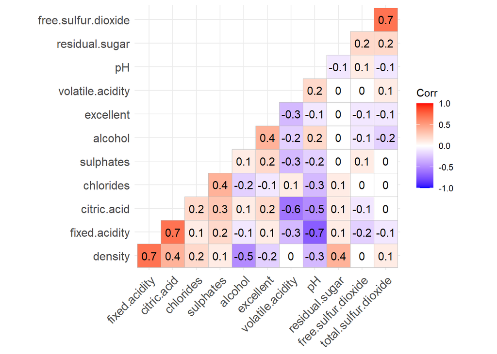

```r
library(corrplot)
library(ggcorrplot)

red_winef <- red_wine[,c("fixed.acidity", "volatile.acidity", "citric.acid", "residual.sugar","chlorides", "free.sulfur.dioxide", "total.sulfur.dioxide", "density", "pH","sulphates","alcohol","excellent") ]
corr <- round(cor(red_winef), 1)
ggcorrplot(corr, hc.order = TRUE, type = "lower", lab = TRUE)
```

From the model, we can see some collinearity between the following: * Fixed acidity and pH * Total sulphur dioxide and free sulphur dioxide * Density and fixed acidity * Fixed acidity and citric acid

However, we will not drop any predictor variables as of now and will go ahead with the full model

Now doing chi-square test to select predictors

```r
drop1(model2, test="Chi")
```

```
## Single term deletions
##
## Model:
## excellent ~ (fixed.acidity + volatile.acidity + citric.acid +
##     residual.sugar + chlorides + free.sulfur.dioxide + total.sulfur.dioxide +
##     density + pH + sulphates + alcohol + quality) - quality
##                      Df Deviance    AIC    LRT  Pr(>Chi)
## <none>                    738.26 762.26
## fixed.acidity         1   743.20 765.20  4.944 0.0261876 *
## volatile.acidity      1   752.49 774.49 14.234 0.0001614 ***
## citric.acid           1   738.29 760.29  0.037 0.8467420
## residual.sugar        1   745.41 767.41  7.159 0.0074586 **
## chlorides             1   744.82 766.82  6.569 0.0103758 *
## free.sulfur.dioxide   1   738.33 760.33  0.077 0.7808876
## total.sulfur.dioxide  1   745.75 767.75  7.496 0.0061824 **
## density               1   742.88 764.88  4.629 0.0314423 *
## pH                    1   738.31 760.31  0.052 0.8200600
## sulphates             1   778.01 800.01 39.758 2.875e-10 ***
## alcohol               1   767.20 789.20 28.945 7.445e-08 ***
## ---
## Signif. codes:  0 '***' 0.001 '**' 0.01 '*' 0.05 '.' 0.1 ' ' 1
```

Removing citric.acid and repeating the chi-square test

```r
model3 <- glm(excellent ~ . -quality -citric.acid , data = red_wine1, family = binomial(link = 'logit'))
```

```r
drop1(model3, test="Chi")
```

```
## Single term deletions
##
## Model:
## excellent ~ (fixed.acidity + volatile.acidity + citric.acid +
##     residual.sugar + chlorides + free.sulfur.dioxide + total.sulfur.dioxide +
##     density + pH + sulphates + alcohol + quality) - quality -
##     citric.acid
##                      Df Deviance    AIC    LRT  Pr(>Chi)
## <none>                    738.29 760.29
## fixed.acidity         1   743.34 763.34  5.049  0.024642 *
## volatile.acidity      1   758.17 778.17 19.881 8.240e-06 ***
## residual.sugar        1   745.42 765.42  7.126  0.007599 **
## chlorides             1   745.84 765.84  7.547  0.006010 **
## free.sulfur.dioxide   1   738.38 758.38  0.090  0.764528
## total.sulfur.dioxide  1   746.16 766.16  7.871  0.005023 **
## density               1   743.11 763.11  4.820  0.028127 *
## pH                    1   738.36 758.36  0.067  0.796075
## sulphates             1   778.06 798.06 39.771 2.855e-10 ***
## alcohol               1   768.65 788.65 30.357 3.594e-08 ***
## ---
## Signif. codes:  0 '***' 0.001 '**' 0.01 '*' 0.05 '.' 0.1 ' ' 1
```

Removing pH and updating the model

```r
model4 <- glm(excellent ~ . -quality -citric.acid -pH, data = red_wine1, family = binomial(link = 'logit'))
drop1(model4, test="Chi")
```

```
## Single term deletions
##
## Model:
## excellent ~ (fixed.acidity + volatile.acidity + citric.acid +
##     residual.sugar + chlorides + free.sulfur.dioxide + total.sulfur.dioxide +
##     density + pH + sulphates + alcohol + quality) - quality -
##     citric.acid - pH
##                      Df Deviance    AIC    LRT  Pr(>Chi)
## <none>                    738.36 758.36
## fixed.acidity         1   748.21 766.21  9.853  0.001695 **
## volatile.acidity      1   758.18 776.18 19.817 8.523e-06 ***
## residual.sugar        1   745.68 763.68  7.317  0.006830 **
## chlorides             1   746.95 764.95  8.587  0.003385 **
## free.sulfur.dioxide   1   738.48 756.48  0.121  0.728075
## total.sulfur.dioxide  1   746.91 764.91  8.553  0.003449 **
## density               1   744.27 762.27  5.907  0.015085 *
## sulphates             1   778.32 796.32 39.961 2.591e-10 ***
## alcohol               1   779.26 797.26 40.896 1.606e-10 ***
## ---
## Signif. codes:  0 '***' 0.001 '**' 0.01 '*' 0.05 '.' 0.1 ' ' 1
```

Again, removing free sulphur dioxide and repeating the Chi-square test

```r
model5 <- glm(excellent ~ . -quality -citric.acid -pH -free.sulfur.dioxide, data = red_wine1, family = binomial(link = 'logit'))
drop1(model5, test="Chi")
```

```
## Single term deletions
##
## Model:
## excellent ~ (fixed.acidity + volatile.acidity + citric.acid +
##     residual.sugar + chlorides + free.sulfur.dioxide + total.sulfur.dioxide +
##     density + pH + sulphates + alcohol + quality) - quality -
##     citric.acid - pH - free.sulfur.dioxide
##                      Df Deviance    AIC    LRT  Pr(>Chi)
## <none>                    738.48 756.48
## fixed.acidity         1   748.25 764.25  9.773 0.0017714 **
## volatile.acidity      1   758.72 774.72 20.241 6.828e-06 ***
## residual.sugar        1   745.68 761.68  7.197 0.0073034 **
## chlorides             1   747.07 763.07  8.587 0.0033854 **
## total.sulfur.dioxide  1   751.70 767.70 13.221 0.0002768 ***
## density               1   744.37 760.37  5.890 0.0152249 *
## sulphates             1   778.65 794.65 40.165 2.334e-10 ***
## alcohol               1   779.45 795.45 40.967 1.549e-10 ***
## ---
## Signif. codes:  0 '***' 0.001 '**' 0.01 '*' 0.05 '.' 0.1 ' ' 1
```

Now, we can see that there is no predictor variable, with insignificant p-value.

Let’s check if step AIC also gives the same model

```r
library(MASS)
stepAIC(model2)
```

```
## Start:  AIC=762.26
## excellent ~ (fixed.acidity + volatile.acidity + citric.acid +
##     residual.sugar + chlorides + free.sulfur.dioxide + total.sulfur.dioxide +
##     density + pH + sulphates + alcohol + quality) - quality
##
##                        Df Deviance    AIC
## - citric.acid           1   738.29 760.29
## - pH                    1   738.31 760.31
## - free.sulfur.dioxide   1   738.33 760.33
## <none>                      738.26 762.26
## - density               1   742.88 764.88
## - fixed.acidity         1   743.20 765.20
## - chlorides             1   744.82 766.82
## - residual.sugar        1   745.41 767.41
## - total.sulfur.dioxide  1   745.75 767.75
## - volatile.acidity      1   752.49 774.49
## - alcohol               1   767.20 789.20
## - sulphates             1   778.01 800.01
##
## Step:  AIC=760.29
## excellent ~ fixed.acidity + volatile.acidity + residual.sugar +
##     chlorides + free.sulfur.dioxide + total.sulfur.dioxide +
##     density + pH + sulphates + alcohol
##
##                        Df Deviance    AIC
## - pH                    1   738.36 758.36
## - free.sulfur.dioxide   1   738.38 758.38
## <none>                      738.29 760.29
## - density               1   743.11 763.11
## - fixed.acidity         1   743.34 763.34
## - residual.sugar        1   745.42 765.42
## - chlorides             1   745.84 765.84
## - total.sulfur.dioxide  1   746.16 766.16
## - volatile.acidity      1   758.17 778.17
## - alcohol               1   768.65 788.65
## - sulphates             1   778.06 798.06
##
## Step:  AIC=758.36
## excellent ~ fixed.acidity + volatile.acidity + residual.sugar +
##     chlorides + free.sulfur.dioxide + total.sulfur.dioxide +
```

[output cut: 14 more lines]

```
## Step:  AIC=756.48
## excellent ~ fixed.acidity + volatile.acidity + residual.sugar +
##     chlorides + total.sulfur.dioxide + density + sulphates +
##     alcohol
##
##                        Df Deviance    AIC
## <none>                      738.48 756.48
## - density               1   744.37 760.37
## - residual.sugar        1   745.68 761.68
## - chlorides             1   747.07 763.07
## - fixed.acidity         1   748.25 764.25
## - total.sulfur.dioxide  1   751.70 767.70
## - volatile.acidity      1   758.72 774.72
## - sulphates             1   778.65 794.65
## - alcohol               1   779.45 795.45
```

```
##
## Call:  glm(formula = excellent ~ fixed.acidity + volatile.acidity +
##     residual.sugar + chlorides + total.sulfur.dioxide + density +
##     sulphates + alcohol, family = binomial(link = "logit"), data = red_wine1)
##
## Coefficients:
##          (Intercept)         fixed.acidity      volatile.acidity
##            231.74374               0.27536              -3.03502
##       residual.sugar             chlorides  total.sulfur.dioxide
##              0.21908              -7.54620              -0.01228
##              density             sulphates               alcohol
##           -245.88353               3.78357               0.76927
##
## Degrees of Freedom: 1358 Total (i.e. Null);  1350 Residual
## Null Deviance:       1078
## Residual Deviance: 738.5     AIC: 756.5
```

We are getting the same model from Chi square test and step AIC, i.e. model5

**2.** Now, pH is not in our final model, and interpretation for alcohol and residual sugar is as follows:

- With 1 unit increase in residual sugar, the odds of wine becoming excellent increase by e^0.21908
- With 1 unit increase in alcohol, the odds of wine becoming excellent increase by e^0.76927

**3** Create the confusion matrix for predicted probabilities

```r
linear_pred <- predict(model5)
pred_prob <- predict(model5, type = "response")

# Predicted outcomes using 0.5 probability
pred_out <- ifelse(pred_prob <0.5, "No", "Yes")

red_wine_c <- data.frame(red_wine1, pred_prob, pred_out)
xtabs(~excellent+pred_out, red_wine_c)
```

```
##          pred_out
## excellent   No  Yes
##         0 1136   39
##         1  122   62
```

Calculating the specificity and sensitivity

```r
specificity <- (1136/ (1136+39))
sensitivity <- (62/(122 + 62))

print(specificity)
```

```
## [1] 0.9668085
```

```r
print(sensitivity)
```

```
## [1] 0.3369565
```

Sensitivity is very low for this model, i.e. we are getting a lot of false negatives in our data

To rectify this, we can decrease the threshold probability to the optimum value, where we get both specificity and sensitivity on the higher side

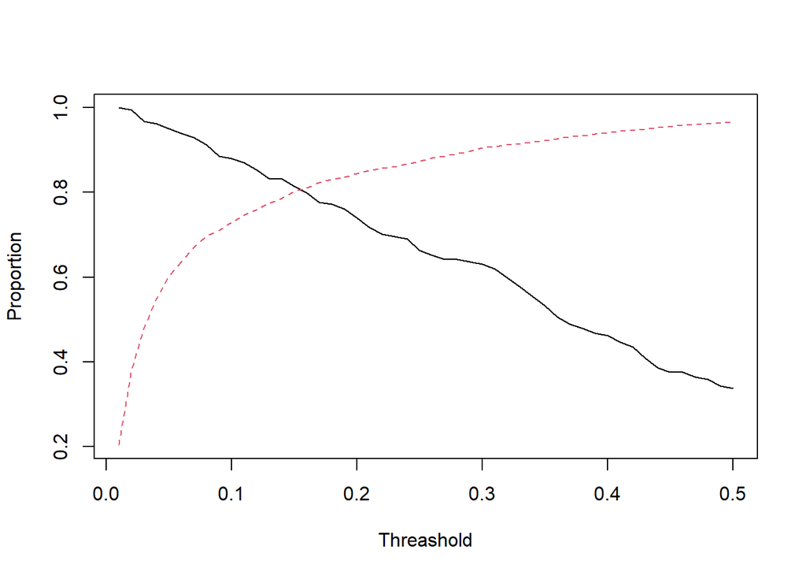

```r
threashold <- seq(0.01, 0.5, 0.01)

sensitivity_1 <- specificity_1 <- rep(NA, length(threashold))

for (j in seq(along = threashold)){
  pp <- ifelse(red_wine_c$pred_prob < threashold[j], "No", "Yes")
  xx <- xtabs(~excellent+pp, red_wine_c)
  specificity_1[j] <- xx[1,1]/(xx[1,1] + xx[1,2])
  sensitivity_1[j] <- xx[2,2]/(xx[2,1] + xx[2,2])
}

matplot(threashold, cbind(sensitivity_1, specificity_1), type = "l", xlab = "Threashold", ylab = "Proportion", lty = 1:2)
```

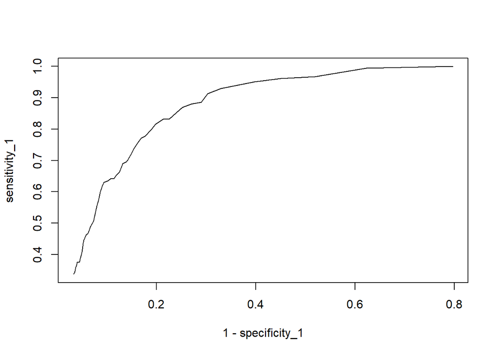

```r
plot(1-specificity_1, sensitivity_1, type = "l")
```

Looking at the above graph, we can approximately take the threashold probability to be around **0.15**

```r
# Predicted outcomes using 0.15 probability
pred_out_final <- ifelse(pred_prob <0.15, "No", "Yes")

xtabs(~excellent+pred_out_final, red_wine_c)
```

```
##          pred_out_final
## excellent  No Yes
##         0 942 233
##         1  34 150
```

We can see significant improvement in the predictions

```r
library(pROC)
library(ROCR)
```

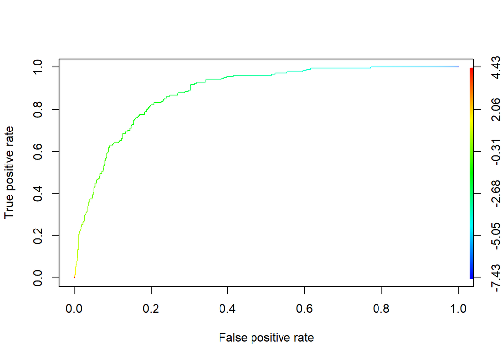

```r
pred_1<- predict(model5, data= red_wine1)
pred_c <- prediction(pred_1, red_wine1$excellent)
performance_m <- performance(pred_c, "tpr", "fpr")
plot(performance_m, colorize=TRUE)
```

```r
unlist(slot(performance(pred_c, "auc"), "y.values"))
```

```
## [1] 0.8833395
```

The AUC for this model is: 0.8833395

**Doing Prediction for 1st and 268th bottle in the dataset**

1. For 1st bottle

```r
predict(model5, red_wine1[1,], type = "link", se = T)
```

```
## $fit
##        1
## -4.91055
##
## $se.fit
## [1] 0.3053951
##
## $residual.scale
## [1] 1
```

```r
predict(model5, red_wine1[1,], type = "response", se = T)
```

```
## $fit
##           1
## 0.007314538
##
## $se.fit
##           1
## 0.002217485
##
## $residual.scale
## [1] 1
```

Calculating Confidence Interval

```r
library(faraway)
round(ilogit(c(-4.91055 - 1.96*0.3053951,-4.91055 + 1.96*0.3053951 )), 3)
```

```
## [1] 0.004 0.013
```

```r
round(c(0.007314538 - 1.96*0.002217485 ,0.007314538 + 1.96*0.002217485 ), 3)
```

```
## [1] 0.003 0.012
```

2. For 268th bottle

```r
predict(model5, red_wine1[268,], type = "link", se = T)
```

```
## $fit
##       268
## -4.694139
##
## $se.fit
## [1] 0.2750547
##
## $residual.scale
## [1] 1
```

```r
predict(model5, red_wine1[268,], type = "response", se = T)
```

```
## $fit
##         268
## 0.009065797
##
## $se.fit
##         268
## 0.002470984
##
## $residual.scale
## [1] 1
```

Confidence Interval

```r
round(ilogit(c(-4.694139  - 1.96*0.2750547,-4.694139  + 1.96*0.2750547)), 3)
```

```
## [1] 0.005 0.015
```

```r
round(c(0.009065797  - 1.96*0.002470984  ,0.009065797  + 1.96*0.002470984  ), 3)
```

```
## [1] 0.004 0.014
```

From above, we can see that we have approximately the same values for confidence interval of predicted probabilities

**Prediction by using optimal threshold value of 0.15 or 0.5**

Since, both the prodicted probabilities are < the threshold probability of 0.15, as well as 0.5, the model is saying that the wines are not excellent, or excellent == 0

Now, let’s look at the actual values

```r
red_wine1[1,]$excellent
```

```
## [1] 0
```

```r
red_wine1[268,]$excellent
```

```
## [1] 0
```

We can see that the actual values are also 0, hence, our model is predicting right

***Part D**: Link Functions and Dispersion Parameter

Fitting the same model with link functions probit and c log log

```r
#Probit Model

red_wine_final <- red_wine1[,c(-12,-14)]

model5_logit <- glm(excellent ~ .-citric.acid -pH -free.sulfur.dioxide , data = red_wine_final, family = binomial(link = 'logit'))

model5_probit <- glm(excellent ~ .-citric.acid -pH -free.sulfur.dioxide , data = red_wine_final, family = binomial(link = 'probit'))

model5_loglog <- glm(excellent ~ . -citric.acid -pH -free.sulfur.dioxide, data =red_wine_final, family = binomial(link = 'cloglog'))
```

```r
summary(model5_logit)
```

```
##
## Call:
## glm(formula = excellent ~ . - citric.acid - pH - free.sulfur.dioxide,
##     family = binomial(link = "logit"), data = red_wine_final)
##
## Deviance Residuals:
##     Min       1Q   Median       3Q      Max
## -2.9782  -0.4353  -0.2188  -0.1253   2.9988
##
## Coefficients:
##                        Estimate Std. Error z value Pr(>|z|)
## (Intercept)           231.74374  101.39529   2.286  0.02228 *
## fixed.acidity           0.27536    0.08851   3.111  0.00186 **
## volatile.acidity       -3.03502    0.70717  -4.292 1.77e-05 ***
## residual.sugar          0.21908    0.07591   2.886  0.00390 **
## chlorides              -7.54620    3.14473  -2.400  0.01641 *
## total.sulfur.dioxide   -0.01228    0.00364  -3.374  0.00074 ***
## density              -245.88353  101.80624  -2.415  0.01573 *
## sulphates               3.78357    0.57688   6.559 5.43e-11 ***
## alcohol                 0.76927    0.12224   6.293 3.11e-10 ***
## ---
## Signif. codes:  0 '***' 0.001 '**' 0.01 '*' 0.05 '.' 0.1 ' ' 1
##
## (Dispersion parameter for binomial family taken to be 1)
##
##     Null deviance: 1077.72  on 1358  degrees of freedom
## Residual deviance:  738.48  on 1350  degrees of freedom
## AIC: 756.48
##
## Number of Fisher Scoring iterations: 6
```

```r
summary(model5_probit)
```

```
##
## Call:
## glm(formula = excellent ~ . - citric.acid - pH - free.sulfur.dioxide,
##     family = binomial(link = "probit"), data = red_wine_final)
##
## Deviance Residuals:
##      Min        1Q    Median        3Q       Max
## -2.99878  -0.45197  -0.20042  -0.08767   3.13821
##
## Coefficients:
##                        Estimate Std. Error z value Pr(>|z|)
## (Intercept)           1.242e+02  5.609e+01   2.214 0.026847 *
## fixed.acidity         1.404e-01  4.831e-02   2.907 0.003655 **
## volatile.acidity     -1.620e+00  3.761e-01  -4.308 1.65e-05 ***
## residual.sugar        1.161e-01  4.272e-02   2.717 0.006583 **
## chlorides            -3.987e+00  1.582e+00  -2.520 0.011722 *
## total.sulfur.dioxide -6.853e-03  1.973e-03  -3.473 0.000514 ***
## density              -1.318e+02  5.628e+01  -2.342 0.019162 *
## sulphates             2.080e+00  3.236e-01   6.428 1.29e-10 ***
## alcohol               4.186e-01  6.745e-02   6.206 5.43e-10 ***
## ---
## Signif. codes:  0 '***' 0.001 '**' 0.01 '*' 0.05 '.' 0.1 ' ' 1
##
## (Dispersion parameter for binomial family taken to be 1)
##
##     Null deviance: 1077.72  on 1358  degrees of freedom
## Residual deviance:  736.01  on 1350  degrees of freedom
## AIC: 754.01
##
## Number of Fisher Scoring iterations: 7
```

```r
summary(model5_loglog)
```

```
##
## Call:
## glm(formula = excellent ~ . - citric.acid - pH - free.sulfur.dioxide,
##     family = binomial(link = "cloglog"), data = red_wine_final)
##
## Deviance Residuals:
##     Min       1Q   Median       3Q      Max
## -7.0856  -0.5190  -0.3031  -0.1972   2.7344
##
## Coefficients:
##                        Estimate Std. Error z value Pr(>|z|)
## (Intercept)           1.618e+02  8.364e+01   1.935  0.05300 .
## fixed.acidity         2.064e-01  6.981e-02   2.957  0.00311 **
## volatile.acidity     -2.469e+00  5.441e-01  -4.537 5.71e-06 ***
## residual.sugar        2.246e-01  8.019e-02   2.801  0.00509 **
## chlorides            -5.996e+00  2.759e+00  -2.173  0.02978 *
## total.sulfur.dioxide -1.039e-02  3.316e-03  -3.132  0.00174 **
## density              -1.723e+02  8.379e+01  -2.057  0.03970 *
## sulphates             2.807e+00  4.341e-01   6.465 1.01e-10 ***
## alcohol               5.503e-01  9.752e-02   5.643 1.67e-08 ***
## ---
## Signif. codes:  0 '***' 0.001 '**' 0.01 '*' 0.05 '.' 0.1 ' ' 1
##
## (Dispersion parameter for binomial family taken to be 1)
##
##     Null deviance: 1077.72  on 1358  degrees of freedom
## Residual deviance:  802.92  on 1350  degrees of freedom
## AIC: 820.92
##
## Number of Fisher Scoring iterations: 25
```

Looking at the AIC, and residual deviance values for the 3 models, we have the following:

**AIC Values:**

logit: 756.48 probit: 754.01 cloglog: 820.92

**Residual Deviance:**

logit: 738.48 probit: 736.01 cloglog: 802.92

Now let’s visualize the ROC curve and compare the AUC values for the 3 models

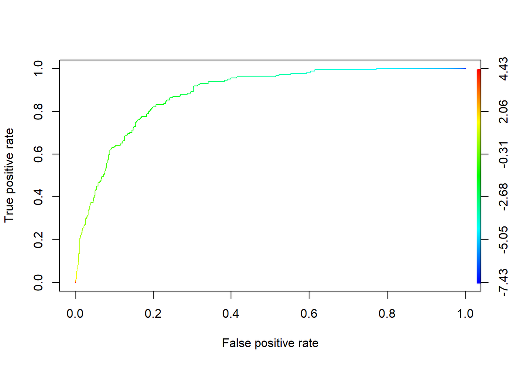

```r
#Logit
pred_1<- predict(model5_logit, data= red_wine_final)
pred_c <- prediction(pred_1, red_wine_final$excellent)
performance_m <- performance(pred_c, "tpr", "fpr")
plot(performance_m, colorize=TRUE)
```

```r
unlist(slot(performance(pred_c, "auc"), "y.values"))
```

```
## [1] 0.8833395
```

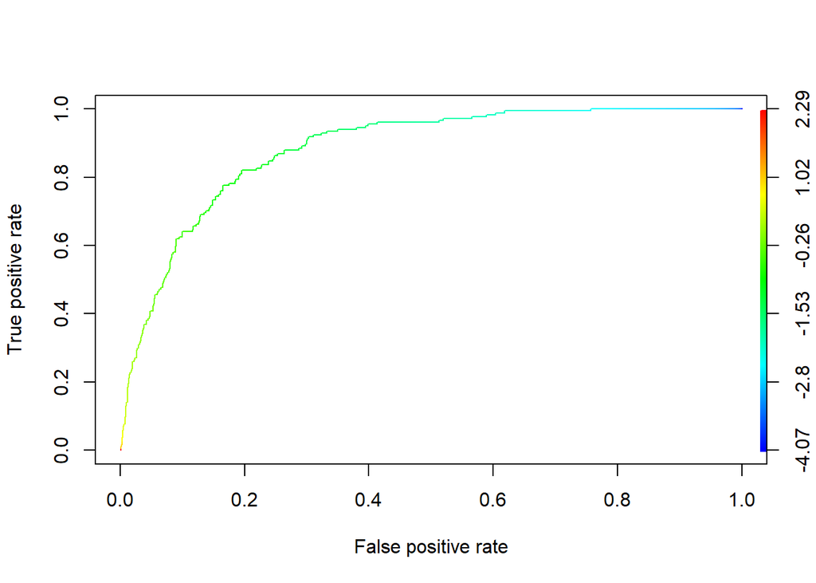

```r
#Probit
pred_2<- predict(model5_probit, data= red_wine_final)
pred_c1 <- prediction(pred_2, red_wine_final$excellent)
performance_m1 <- performance(pred_c1, "tpr", "fpr")
plot(performance_m1, colorize=TRUE)
```

```r
unlist(slot(performance(pred_c1, "auc"), "y.values"))
```

```
## [1] 0.883136
```

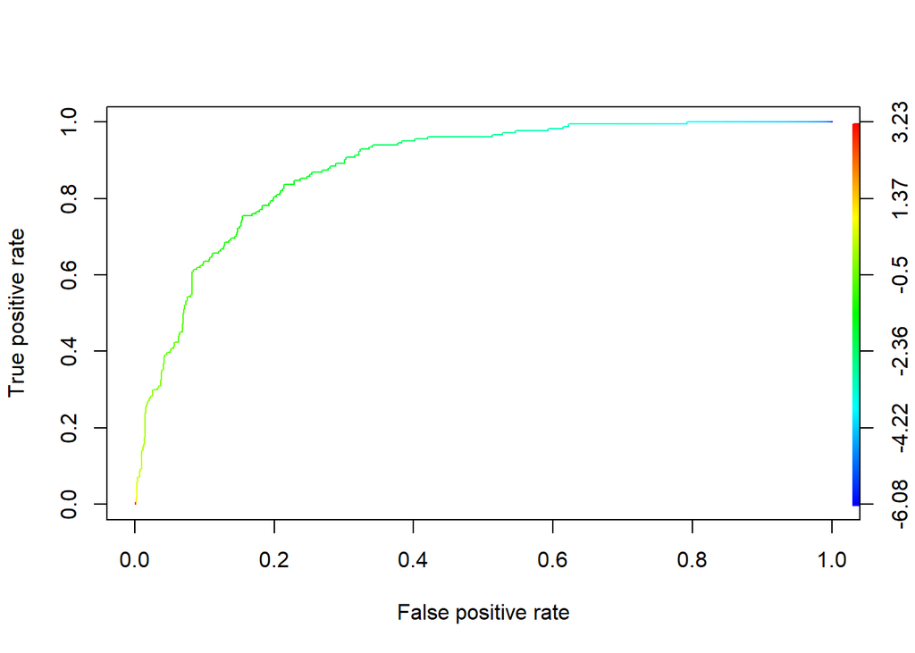

```r
#cloglog
pred_3<- predict(model5_loglog, data= red_wine_final)
pred_c2 <- prediction(pred_3, red_wine_final$excellent)
performance_m2 <- performance(pred_c2, "tpr", "fpr")
plot(performance_m2, colorize=TRUE)
```

```r
unlist(slot(performance(pred_c2, "auc"), "y.values"))
```

```
## [1] 0.8820259
```

Comapring the AUC value for the 3 models:

- Logit: 0.8833395
- Probit: 0.883136
- cloglog: 0.8820259

We can see that the AUC values for logit model is marginally higher, followed by probit and cloglog.

Checking for the predicted probabilities of 3 models on the higher tail of the curve

```r
predval <- sapply(list(model5_logit, model5_probit, model5_loglog), fitted)
round(predval[fitted(model5_logit) > 0.70,],3)
```

```
##       [,1]  [,2]  [,3]
## 128  0.790 0.759 0.820
## 243  0.858 0.821 0.978
## 303  0.739 0.689 0.821
## 324  0.860 0.829 0.950
## 332  0.855 0.819 0.966
## 378  0.726 0.677 0.782
## 409  0.859 0.828 0.936
## 431  0.798 0.759 0.869
## 432  0.868 0.838 0.949
## 511  0.720 0.691 0.728
## 566  0.988 0.989 1.000
## 697  0.795 0.757 0.875
## 698  0.774 0.735 0.848
## 711  0.763 0.733 0.791
## 804  0.708 0.662 0.822
## 885  0.736 0.694 0.857
## 898  0.725 0.688 0.780
## 949  0.732 0.696 0.781
## 959  0.702 0.671 0.729
## 965  0.833 0.801 0.891
## 982  0.749 0.712 0.824
## 1082 0.734 0.701 0.720
## 1083 0.768 0.736 0.781
## 1196 0.781 0.743 0.844
```

Even though the absolute probability values differ (clog log is giving higher probability towards the upper tail); all of them are predicting the same thing, i.e. the selected wines are excellent, as they are all above the threshold of 0.15 or even 0.5

Based on all of the above factors, we can concluded that **probit** model can be considered the best among these

Updating the dispersion coefficient for the model

```r
sigma_squared <- sum(residuals(model5_logit, type = "pearson")^2)/(nrow(red_wine_final)-9)

summary(model5_logit, dispersion = sigma_squared)
```

```
##
## Call:
## glm(formula = excellent ~ . - citric.acid - pH - free.sulfur.dioxide,
##     family = binomial(link = "logit"), data = red_wine_final)
##
## Deviance Residuals:
##     Min       1Q   Median       3Q      Max
## -2.9782  -0.4353  -0.2188  -0.1253   2.9988
##
## Coefficients:
##                        Estimate Std. Error z value Pr(>|z|)
## (Intercept)           231.74374   93.62094   2.475 0.013311 *
## fixed.acidity           0.27536    0.08172   3.369 0.000753 ***
## volatile.acidity       -3.03502    0.65295  -4.648 3.35e-06 ***
## residual.sugar          0.21908    0.07009   3.126 0.001773 **
## chlorides              -7.54620    2.90361  -2.599 0.009352 **
## total.sulfur.dioxide   -0.01228    0.00336  -3.655 0.000258 ***
## density              -245.88353   94.00038  -2.616 0.008903 **
## sulphates               3.78357    0.53265   7.103 1.22e-12 ***
## alcohol                 0.76927    0.11287   6.816 9.38e-12 ***
## ---
## Signif. codes:  0 '***' 0.001 '**' 0.01 '*' 0.05 '.' 0.1 ' ' 1
##
## (Dispersion parameter for binomial family taken to be 0.8525315)
##
##     Null deviance: 1077.72  on 1358  degrees of freedom
## Residual deviance:  738.48  on 1350  degrees of freedom
## AIC: 756.48
##
## Number of Fisher Scoring iterations: 6
```

The **standard error** for each of the predictor variables **decreased** after adjusting for the dispersion parameter, the *coefficient values, AIC and residual deviance* of the model **remains the same**.

**Part E:** Modeling the wine quality as Multinomial variable with order

**1. Extracting unique quality values and then plotting histograms**

```r
red_wine_m <- red_wine1[,c(-13,-14,-15)]

red_wine_m$quality_f <- as.factor(red_wine_m$quality)
red_wine_m$quality <- as.numeric(red_wine_m$quality)
levels(red_wine_m$quality_f)
```

```
## [1] "3" "4" "5" "6" "7" "8"
```

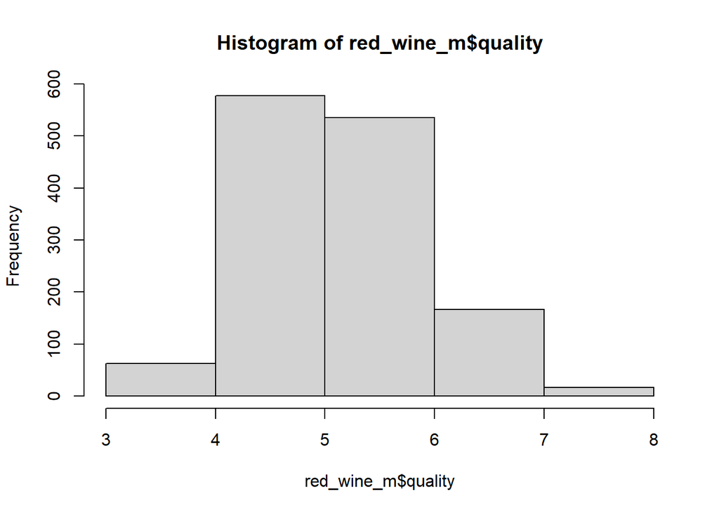

```r
hist(red_wine_m$quality, breaks = 4)
```

Since, this is ordinal data, we will trat this data having multinomial distribution with order, and model it accordingly

Calculating the kendall correlation coefficient and arranging the predictors according to absolute value of their coerrelation coefficient with the quality variable

```r
corr1 <- cor(red_wine_m$quality, red_wine_m[, c(-12, -13)], method = c("kendall"))
rank <- corr1[, order(abs(corr1), decreasing = TRUE)]
rank <- data.frame(rank)
rank
```

```
##                             rank
## alcohol               0.38762105
## volatile.acidity     -0.30566780
## sulphates             0.30175147
## citric.acid           0.17155329
## chlorides            -0.16008014
## total.sulfur.dioxide -0.15662649
## density              -0.14206660
## fixed.acidity         0.08579860
## free.sulfur.dioxide  -0.04728373
## pH                   -0.03331232
## residual.sugar        0.02060841
```

Taking top 5 predictors (excluding citric acid, since it has good correlation with volatile acidity and it does not fit the model well when added)

**5. Fitting the model on ordinal data, i.e. quality**

```r
library(VGAM)
model6 <- vglm(quality ~ .  -pH -quality  -quality_f -citric.acid - fixed.acidity - residual.sugar - density - free.sulfur.dioxide, family = cumulative(parallel = TRUE), red_wine_m)

summary(model6)
```

```
##
## Call:
## vglm(formula = quality ~ . - pH - quality - quality_f - citric.acid -
##     fixed.acidity - residual.sugar - density - free.sulfur.dioxide,
##     family = cumulative(parallel = TRUE), data = red_wine_m)
##
## Coefficients:
##                       Estimate Std. Error z value Pr(>|z|)
## (Intercept):1         2.406717   0.755242   3.187  0.00144 **
## (Intercept):2         4.337394   0.697675   6.217 5.07e-10 ***
## (Intercept):3         7.893720   0.698059  11.308  < 2e-16 ***
## (Intercept):4        10.707212   0.737702  14.514  < 2e-16 ***
## (Intercept):5        13.596682   0.797780  17.043  < 2e-16 ***
## volatile.acidity      3.453217   0.329633  10.476  < 2e-16 ***
## chlorides             5.058755   1.274659   3.969 7.23e-05 ***
## total.sulfur.dioxide  0.006942   0.001698   4.089 4.33e-05 ***
## sulphates            -2.833364   0.370332  -7.651 2.00e-14 ***
## alcohol              -0.852653   0.058817 -14.497  < 2e-16 ***
## ---
## Signif. codes:  0 '***' 0.001 '**' 0.01 '*' 0.05 '.' 0.1 ' ' 1
##
## Number of linear predictors:  5
##
## Names of linear predictors: logitlink(P[Y<=1]), logitlink(P[Y<=2]),
## logitlink(P[Y<=3]), logitlink(P[Y<=4]), logitlink(P[Y<=5])
##
## Residual deviance: 2675.954 on 6785 degrees of freedom
##
## Log-likelihood: -1337.977 on 6785 degrees of freedom
##
## Number of Fisher scoring iterations: 6
##
## No Hauck-Donner effect found in any of the estimates
##
##
## Exponentiated coefficients:
##     volatile.acidity            chlorides total.sulfur.dioxide
##          31.60189277         157.39446563           1.00696574
##            sulphates              alcohol
##           0.05881468           0.42628254
```

**Key differences between the logistic and multinomial ordered model**

- In the logistic model, we got a good model with 8 predictors, however, in this model, we are getting a model with only 5 predictors
- Also, the direction of the coefficients is opposite, when compared with logistic regression.

Additionally, we can draw the following implication from exponentiated coefficients:

For 1 unit increase in alcohol, odds of quality being, **3, 4, 5, 6 and 7**, chnages by 0.4263 times the odds of quality being 8.

Calculating the probability of 1st and 268th bottle using predictvglm function

```r
# 1st bottle
a <- predictvglm(model6, type = "response", newdata = as.data.frame(red_wine_m[1,]))
a
```

```
##            3          4         5         6          7            8
## 1 0.01541055 0.08198572 0.6934163 0.1935653 0.01474042 0.0008816864
```

```r
prob_atleast_7_1 <- sum(a[,"7"], a[,"8"])
paste("Probability for 1st bottle is:", round(prob_atleast_7_1,4))
```

```
## [1] "Probability for 1st bottle is: 0.0156"
```

```r
#268th bottle
b <- predictvglm(model6, type = "response", newdata = as.data.frame(red_wine_m[268,]))
b
```

```
##              3          4         5         6          7            8
## 268 0.01550584 0.08244228 0.6938984 0.1926273 0.01464992 0.0008761877
```

```r
prob_atleast_7_268 <- sum(a[,"7"], a[,"8"])
paste("Probability for 1st bottle is:", round(prob_atleast_7_268,4))
```

```
## [1] "Probability for 1st bottle is: 0.0156"
```

Using the model5 of the logistic regression

```r
predict(model5, red_wine1[1,], type = "response")
```

```
##           1
## 0.007314538
```

```r
predict(model5, red_wine1[268,], type = "response")
```

```
##         268
## 0.009065797
```

Clearly, we can see that we are getting different values for the probabilities.

However, for a threshold value of 0.5, both the models will predict the same response, i.e. wine is not excellent.